# Research Report 1

Author

Rached Abir

Published

February 1, 2026

# Introduction

Automated vehicles can face moral dilemmas too. At least the programmers of these latter do when deciding what a vehicle should do where harm cannot be avoided and one group must be prioritized over another. The Moral Machine project (Awad et al., 2018, Nature) collected large-scale responses to these dilemmas and showed two broad patterns: people share some common moral priorities, but preferences also differ across societies.

To ensure a clearer understanding of my manipulations, let me start by explaining the design of the original study by Awad et al. The experiment varied nine moral factors across scenarios. Six factors related to the type of characters involved: age, gender, fitness, social status, species, and utilitarian. Each condition had two levels. The first compared people’s preferences between saving the young or the elderly. The second choice had to do with male vs. female. The fitness factor compared preferences of saving fit vs. fat. Social status condition’s two levels were high vs. low, meaning richer or poorer. Species compared between saving humans or saving pets. Three additional factors, had to do with the context. These were whether the car swerves or stays on course, whether the victims are passengers or pedestrians, and whether pedestrians are crossing legally or illegally. In our manipulation we will focus on the factors which showed the presence of some sort of preference.

The original study found strong regularities, such as preferring to save more lives, humans rather than animals, and younger rather than older people. At the same time, it identified meaningful cross-country variation and cultural clustering. This led me to wonder if deviation against the majority also follows these same trends. This makes the dataset useful for testing whether disagreement follows social patterns rather than pure randomness.

In this report, I focus on **deviation from global majority preferences** as the outcome. I test whether deviation changes across scenario types (H1), across cultural contexts (H2), and whether cultural differences depend on scenario type (H3).

These hypotheses are substantively important because they test more generally whether moral disagreement is structured by social context and dilemma content. If deviation is patterned rather than random, this has implications for how societies discuss fairness, risk, and responsibility in automated systems. In other words, the question is not only what people choose, but whether disagreement itself follows social regularities.

## Hypotheses:

**H1:** Deviation from global majority moral preferences varies systematically across scenario types.

**H2:** Deviation from global majority moral preferences is structured by cultural context.

**H3:** The effect of cultural context on deviation from global majority moral preferences depends on scenario type.

# Hypothesis testing:

## Data Transformation

To test my hypotheses I used the Moral Machine first-session response data and merged it with a country-to-cultural-context file.

The transformation is done in three steps. First, I needed to filter observations so that they refered to the outcomes only. This is why I kept one observation per distinct respondent and scenario (`Saved == 1`), so each observation represents a clear decision. Second, I define a benchmark table (`majority_map`) that specifies the global-majority option for each scenario type used here (Age, Utilitarian, Species, Fitness). Third, I create a binary variable `against_majority` equal to 1 when the respondent’s choice differs from that benchmark and 0 otherwise.

I then merge country-level cultural context and remove missing context labels (including blank strings, in the case of one country). This produces a clean dataset where each row can be interpreted as: “in this scenario, this respondent either followed or deviated from the global majority preference.”

```r
# Load respondent-level Moral Machine data
df <- readRDS("fullRsample.rds")
```

```r
#Load country-to-cultural-context lookup table
culture <- read.csv("cultures.csv")
```

```r
# Define the global-majority option for each scenario type so that only the conditions that showed consistent majority preference are kept.

majority_map <- tibble::tibble(
  ScenarioTypeStrict = c("Age", "Utilitarian", "Species", "Fitness"),
  majority_attribute = c("Young", "More", "Hoomans", "Fit")
)
knitr::kable(majority_map, caption = "Global-majority benchmark used to define deviation")
```

Global-majority benchmark used to define deviation

| ScenarioTypeStrict | majority_attribute |
| --- | --- |
| Age | Young |
| Utilitarian | More |
| Species | Hoomans |
| Fitness | Fit |

Attributes such as gender or social status are omitted because their effects, while present, are weak, culturally variable, and lack a consistent global majority direction, unlike the core attributes retained in the table.

```r
library(dplyr)

# Keep one observation per respondent and scenario, based on the chosen option.
scenario_data <- df %>%
  group_by(ResponseID, UserID, ScenarioTypeStrict,UserCountry3) %>%
  filter(sum(Saved == 1, na.rm = TRUE) == 1) %>%  # exactly one chosen
  summarise(
    chosen_attribute = AttributeLevel[Saved == 1][1],
    .groups = "drop"
  )
```

```r
# Flag whether each response deviates from the global-majority benchmark we set previously.
scenario_flagged <- scenario_data %>%
  inner_join(majority_map, by = "ScenarioTypeStrict") %>%
  mutate(against_majority = as.integer(chosen_attribute != majority_attribute)) %>%
  left_join(culture, by = c("UserCountry3" = "countries")) %>%
  rename(cultural_context = categories) %>%
  filter(!is.na(cultural_context), !is.na(ScenarioTypeStrict), !is.na(against_majority))
```

```r
# Clean cultural context labels since there are different values that indicate NA in the dataset
scenario_flagged <- scenario_flagged %>%
  mutate(
    cultural_context = trimws(cultural_context),
    cultural_context = na_if(cultural_context, ""),
    cultural_context = na_if(cultural_context, "NA"),
    cultural_context = na_if(cultural_context, "N/A")
  ) %>%
  filter(!is.na(cultural_context))
```

## Descriptive Statistics

### Scenario level tests (H1):

```r
# Compute scenario-level descriptives.
scenario_desc <- scenario_flagged %>%
  group_by(ScenarioTypeStrict) %>%
  summarise(
    n = n(),
    prop_against = mean(against_majority, na.rm = TRUE),
    divisiveness_index = 1 - 2 * abs(prop_against - 0.5), # rescales the distance from a 50/50 split to the unit interval.

# divisiveness_index rescales how close the split is to 50/50:
#   1 = most divisive (exactly 50/50), 0 = strongest consensus.
    .groups = "drop"
  ) %>%
  arrange(desc(divisiveness_index))
```

```r
knitr::kable(scenario_desc, digits = 3, caption = "Scenario-type descriptives")
```

Scenario-type descriptives

| ScenarioTypeStrict | n | prop_against | divisiveness_index |
| --- | --- | --- | --- |
| Fitness | 8200 | 0.469 | 0.937 |
| Age | 8334 | 0.263 | 0.525 |
| Utilitarian | 8550 | 0.226 | 0.452 |
| Species | 8347 | 0.200 | 0.399 |

The divisiveness index is defined as `1 - 2 * |prop_against - 0.5|`, which rescales the distance from a 50/50 split to the unit interval. Values closer to 1 indicate a near-even split (high disagreement); values closer to 0 indicate strong consensus. This is important because it directly quantifies how polarized each scenario type is, beyond just the raw proportion.

Fitness is the most divisive scenario type (prop_against = 0.469, divisiveness_index = 0.937), meaning responses are close to a 50/50 split. Species is the least divisive (prop_against = 0.200, divisiveness_index = 0.399), indicating stronger consensus with the global majority. Age and Utilitarian are intermediate but still clearly less divisive than Fitness.

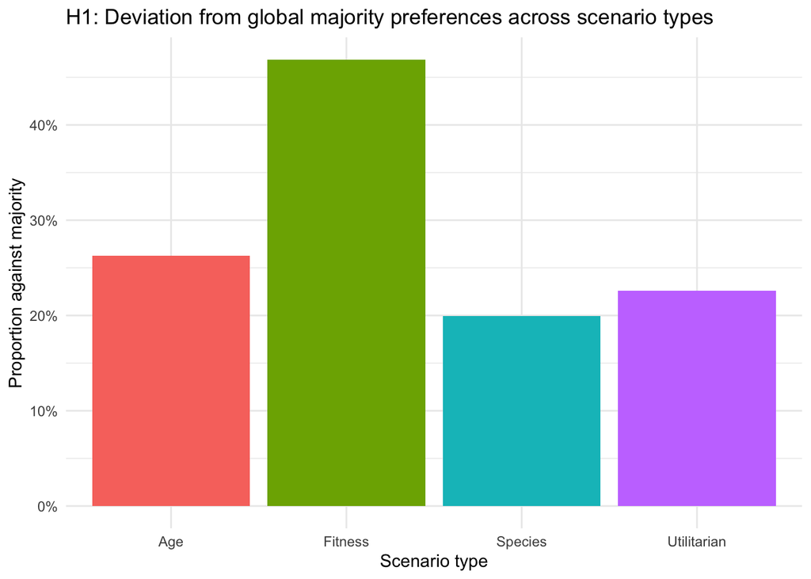

```r
library(ggplot2)
library(scales)

ggplot(scenario_desc, aes(x = ScenarioTypeStrict, y = prop_against, fill = ScenarioTypeStrict)) +
  geom_col(show.legend = FALSE) +
  scale_y_continuous(labels = percent_format(accuracy = 1)) +
  labs(
    title = "H1: Deviation from global majority preferences across scenario types",
    x = "Scenario type",
    y = "Proportion against majority"
  ) +
  theme_minimal()
```

This graph further illustrates the distribution of against-majority answers, with species being the least divisive scenario type (20%), and fitness being the most divisive (46,9%). This supports the claim that disagreement varies by scenario type.

### Cultural context tests (H2):

```r
# Aggregate to country level so each country contributes one mean proportion.
country_data <- scenario_flagged %>%
  group_by(UserCountry3, cultural_context) %>%
  summarise(
    n = n(),
    prop_against = mean(against_majority, na.rm = TRUE),
    .groups = "drop"
  ) %>%
  filter(n >= 200)

culture_desc <- country_data %>%
  group_by(cultural_context) %>%
  summarise(
    n_countries = n(),
    mean_prop_against = mean(prop_against, na.rm = TRUE),
    sd_prop_against = sd(prop_against, na.rm = TRUE),
    .groups = "drop"
  ) %>%
  arrange(desc(mean_prop_against))
```

```r
knitr::kable(culture_desc, digits = 3, caption = "Cultural-context descriptives")
```

Cultural-context descriptives

| cultural_context | n_countries | mean_prop_against | sd_prop_against |
| --- | --- | --- | --- |
| Confucian | 1 | 0.327 | NA |
| LatinAmerica | 3 | 0.307 | 0.024 |
| Orthodox | 3 | 0.302 | 0.025 |
| Protestant | 7 | 0.288 | 0.020 |
| English | 5 | 0.287 | 0.026 |
| Islamic | 1 | 0.285 | NA |
| Catholic | 10 | 0.278 | 0.030 |
| SouthAsia | 1 | 0.230 | NA |

Average deviation rates vary across cultural contexts, from 0.230 (SouthAsia) to 0.327 (Confucian). However, some categories have only one country (Confucian, Islamic, SouthAsia), so their standard deviation is NA and those means should be interpreted cautiously. The categories with more countries (Catholic, Protestant, English) provide more stable descriptive estimates.

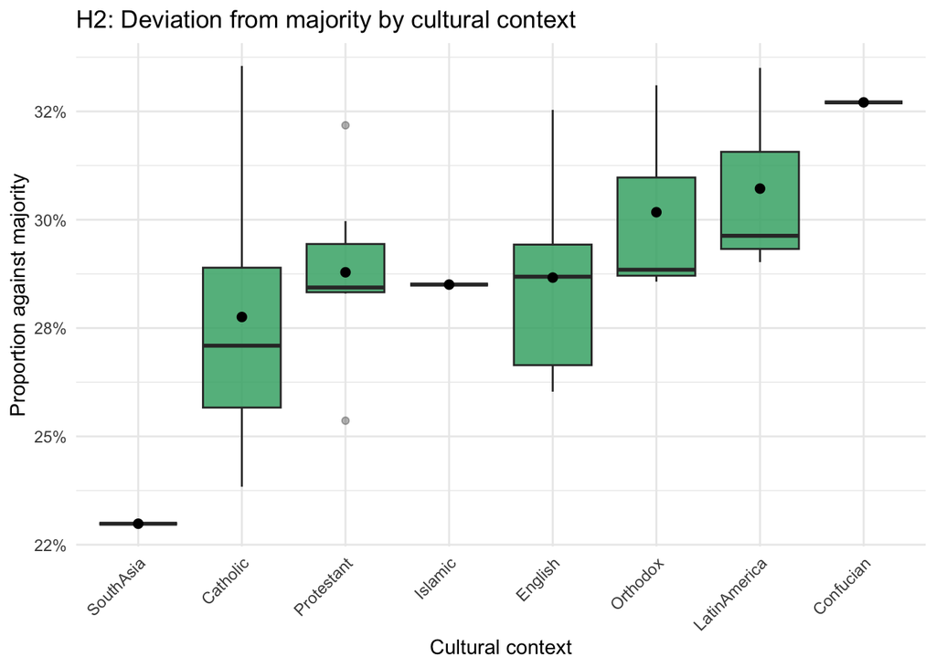

```r
ggplot(country_data, aes(x = reorder(cultural_context, prop_against, median), y = prop_against)) +
  geom_boxplot(fill = "#41AE76", alpha = 0.85, outlier.alpha = 0.35) +
  stat_summary(fun = mean, geom = "point", color = "black", size = 2) +
  scale_y_continuous(labels = percent_format(accuracy = 1)) +
  labs(
    title = "H2: Deviation from majority by cultural context",
    x = "Cultural context",
    y = "Proportion against majority"
  ) +
  theme_minimal() +
  theme(axis.text.x = element_text(angle = 45, hjust = 1))
```

This figure visually matches the descriptive table: the distribution of country-level deviation differs across cultural contexts, but differences are moderate.

### Interaction between cultural context and scenario type test (H3):

```r
# Create country x scenario cells for H3 interaction testing.
cell_data <- scenario_flagged %>%
  group_by(UserCountry3, cultural_context, ScenarioTypeStrict) %>%
  summarise(
    n = n(),
    prop_against = mean(against_majority, na.rm = TRUE),
    .groups = "drop"
  ) %>%
  filter(n >= 100)
```

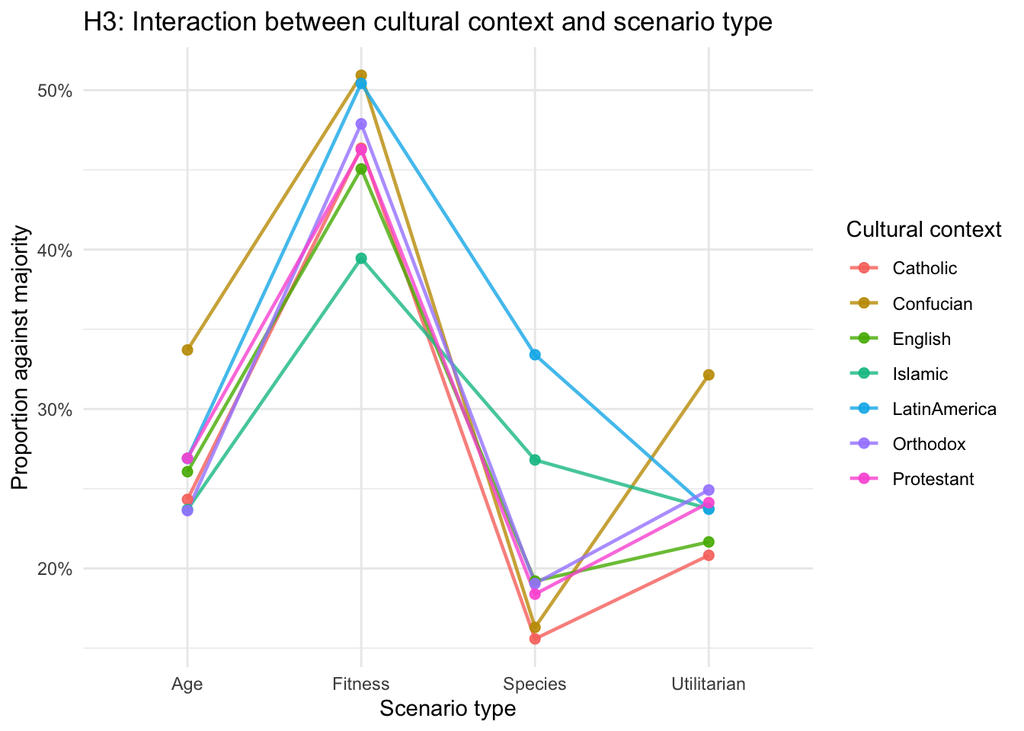

```r
ggplot(cell_data, aes(x = ScenarioTypeStrict, y = prop_against, color = cultural_context, group = cultural_context)) +
  stat_summary(fun = mean, geom = "line", linewidth = 0.8, alpha = 0.8) +
  stat_summary(fun = mean, geom = "point", size = 2, alpha = 0.9) +
  scale_y_continuous(labels = percent_format(accuracy = 1)) +
  labs(
    title = "H3: Interaction between cultural context and scenario type",
    x = "Scenario type",
    y = "Proportion against majority",
    color = "Cultural context"
  ) +
  theme_minimal()
```

The non-parallel lines in this plot suggest a possible interaction: the size of scenario-type differences is not identical across cultural contexts. This is a descriptive signal that motivates the formal H3 interaction test.

The descriptive statistics section suggests three patterns: scenario types differ in divisiveness, cultural groups differ in average deviation, and these differences may not be parallel across scenario types. I now test these formally with inferential statistics: a chi-square test for H1 (categorical association), a weighted ANOVA for H2 (country-level mean differences by cultural context), and an interaction model comparison for H3 (whether scenario effects vary by cultural context).

## Inferential Statistics

I use three inferential tests because each hypothesis asks a different statistical question.

- **H1 (scenario type differences):** I use a **chi-square test of independence** because both variables are categorical (`ScenarioTypeStrict` and binary `against_majority`). This tests whether the distribution of deviation is the same across scenario types.
- **H2 (cultural context differences):** I use a **one-way ANOVA** at country level (`prop_against ~ cultural_context`, weighted by `n`) because the outcome is a country-level proportion and the hypothesis asks whether *group means differ* across cultural contexts.
- **H3 (interaction):** I fit additive and interaction linear models and compare them with **ANOVA model comparison**. This directly tests whether adding `cultural_context × ScenarioTypeStrict` improves fit, which corresponds to the interaction hypothesis.

### Scenario level tests (H1):

```r
# Re-compute scenario-level divisiveness for H1 reporting.

scenario_desc <- scenario_flagged %>%
  group_by(ScenarioTypeStrict) %>%
  summarise(
    n = n(),
    prop_against = mean(against_majority, na.rm = TRUE),
    divisiveness_index = 1 - 2 * abs(prop_against - 0.5), # 1 = most divisive, 0 = strongest consensus
    .groups = "drop"
  ) %>%
  arrange(desc(divisiveness_index))

knitr::kable(scenario_desc, digits = 3, caption = "H1 descriptive: divisiveness by scenario type")
```

H1 descriptive: divisiveness by scenario type

| ScenarioTypeStrict | n | prop_against | divisiveness_index |
| --- | --- | --- | --- |
| Fitness | 8200 | 0.469 | 0.937 |
| Age | 8334 | 0.263 | 0.525 |
| Utilitarian | 8550 | 0.226 | 0.452 |
| Species | 8347 | 0.200 | 0.399 |

I use a chi‑square test of independence because both variables are categorical: scenario type and a binary indicator of deviation. The test evaluates whether the distribution of “against majority” responses is the same across scenario types. If the distributions differ, it means scenario type is associated with deviation rates.

```r
# H1 chi-square test of independence
tab_h1 <- table(scenario_flagged$ScenarioTypeStrict, scenario_flagged$against_majority)
chisq_h1 <- chisq.test(tab_h1)

h1_test <- tibble::tibble(
  statistic = as.numeric(chisq_h1$statistic),
  df = as.numeric(chisq_h1$parameter),
  p_value_raw = chisq_h1$p.value,
  p_value_display = format(chisq_h1$p.value, scientific = TRUE),
  cramer_v = sqrt(as.numeric(chisq_h1$statistic) / (sum(tab_h1) * (min(dim(tab_h1)) - 1)))
)

h1_table <- as.data.frame.matrix(tab_h1)
h1_table <- tibble::rownames_to_column(h1_table, var = "ScenarioTypeStrict")

knitr::kable(h1_table, caption = "H1 contingency table: Scenario Type × Against Majority")
```

H1 contingency table: Scenario Type × Against Majority

| ScenarioTypeStrict | 0 | 1 |
| --- | --- | --- |
| Age | 6145 | 2189 |
| Fitness | 4358 | 3842 |
| Species | 6681 | 1666 |
| Utilitarian | 6616 | 1934 |

The contingency table shows clear differences in the share of against-majority choices by scenario type (for example, Fitness has far more “1” responses than Species)

```r
knitr::kable(h1_test, digits = 4, caption = "H1 inferential test: chi-square (Scenario Type × Against Majority)")
```

H1 inferential test: chi-square (Scenario Type × Against Majority)

| statistic | df | p_value_raw | p_value_display | cramer_v |
| --- | --- | --- | --- | --- |
| 1806.564 | 3 | 0 | 0e+00 | 0.2325 |

The chi-square result is statistically significant (χ² = 1806.564, df = 3, p < 2.2e-16) with a meaningful effect size (Cramer’s V = 0.2325), so we reject independence between scenario type and deviation. This supports **(H1)** that deviation from global majority preferences varies systematically across scenario types.

Substantively, this means some dilemmas are more polarizing than others. In this dataset, `Fitness` is closest to a split opinion, while `Species` shows stronger consensus.

We need to run an assumption check because the chi‑square test relies on an **approximation** to the true sampling distribution. That approximation is only accurate when expected counts in the contingency table are not too small. If expected counts are tiny, the chi‑square p‑value can be biased and the test may be invalid. The assumption check process is: (1) compute expected cell counts under independence; (2) confirm expected counts are not too small; (3) proceed with the chi-square approximation only if those thresholds are met.

```r
h1_assumptions <- tibble::tibble(
  check = c("Minimum expected cell count", "Any expected count < 5?", "Any expected count < 1?"),
  value = c(
    round(min(chisq_h1$expected), 3),
    ifelse(any(chisq_h1$expected < 5), "Yes", "No"),
    ifelse(any(chisq_h1$expected < 1), "Yes", "No")
  )
)
knitr::kable(h1_assumptions, digits = 4, caption = "H1 chi-square assumption checks")
```

H1 chi-square assumption checks

| check | value |
| --- | --- |
| Minimum expected cell count | 2362.304 |
| Any expected count < 5? | No |
| Any expected count < 1? | No |

In our case, the minimum expected cell count is far above 5, and there are no expected counts below 5 or 1. Therefore, the chi-square approximation is appropriate and the H1 inference is valid.

```r
# Standardized residuals highlight which cells deviate most from independence.
h1_stdres <- as.data.frame(chisq_h1$stdres)
h1_stdres$ScenarioTypeStrict <- rownames(chisq_h1$stdres)
knitr::kable(h1_stdres, digits = 3, caption = "H1 standardized residuals (cell-level deviations)")
```

H1 standardized residuals (cell-level deviations)

| Var1 | Var2 | Freq | ScenarioTypeStrict |
| --- | --- | --- | --- |
| Age | 0 | 5.916 | Age |
| Fitness | 0 | -41.533 | Fitness |
| Species | 0 | 20.610 | Species |
| Utilitarian | 0 | 14.647 | Utilitarian |
| Age | 1 | -5.916 | Age |
| Fitness | 1 | 41.533 | Fitness |
| Species | 1 | -20.610 | Species |
| Utilitarian | 1 | -14.647 | Utilitarian |

Standardized residuals show which cells contribute most to the association. Larger absolute residuals (Fitness) indicate scenario-type/response combinations that occur more (or less) often than expected under independence. They are essentially z-scores for each cell: `(observed − expected) / SD(expected)`. Large absolute values indicate scenario-type/response combinations that occur much more (positive) or much less (negative) than expected under independence.

### Cultural context tests (H2):

```r
country_data <- scenario_flagged %>%
  group_by(UserCountry3, cultural_context) %>%
  summarise(
    n = n(),
    prop_against = mean(against_majority, na.rm = TRUE),
    .groups = "drop"
  ) %>%
  filter(n >= 200)
```

For H2, I test whether the **mean** country-level deviation differs across cultural contexts. A one-way ANOVA answers this directly because it is designed to test whether group means differ beyond what would be expected by chance. I use weights (`n`) so that countries with larger samples contribute proportionally more information.

```r
fit_h2 <- lm(prop_against ~ cultural_context, data = country_data, weights = n)

# One-way ANOVA (weighted by country sample size)
fit_h2 <- aov(prop_against ~ cultural_context, data = country_data, weights = n)
h2_anova <- broom::tidy(fit_h2)
# Fit stats from lm (same model)
fit_h2_lm <- lm(prop_against ~ cultural_context, data = country_data, weights = n)
h2_glance <- broom::glance(fit_h2_lm) %>%
  transmute(
    r_squared = r.squared,
    adj_r_squared = adj.r.squared,
    sigma = sigma,
    statistic_F = statistic,
    p_value_model = p.value,
    df_model = df,
    n_obs = nobs
  )
knitr::kable(h2_anova, digits = 4, caption = "H2 ANOVA table: cultural context differences")
```

H2 ANOVA table: cultural context differences

| term | df | sumsq | meansq | statistic | p.value |
| --- | --- | --- | --- | --- | --- |
| cultural_context | 7 | 7.8353 | 1.1193 | 3.5319 | 0.0101 |
| Residuals | 23 | 7.2891 | 0.3169 | NA | NA |

```r
knitr::kable(h2_glance, digits = 4, caption = "H2 model fit summary")
```

H2 model fit summary

| r_squared | adj_r_squared | sigma | statistic_F | p_value_model | df_model | n_obs |
| --- | --- | --- | --- | --- | --- | --- |
| 0.5181 | 0.3714 | 0.563 | 3.5319 | 0.0101 | 7 | 31 |

With R² = 0.518 and Adj. R² = 0.371, the model fit is moderate at the country level, so cultural context accounts for a meaningful (but not exhaustive) share of cross‑country variation in deviation. The gap between R² and adjusted R² suggests caution because the sample is modest (31 countries) relative to the number of cultural categories.

The ANOVA F‑test is significant (F = 3.5319, p = 0.0101), so we conclude that cultural context is associated with different average deviation levels. This supports **H2** at the model level.

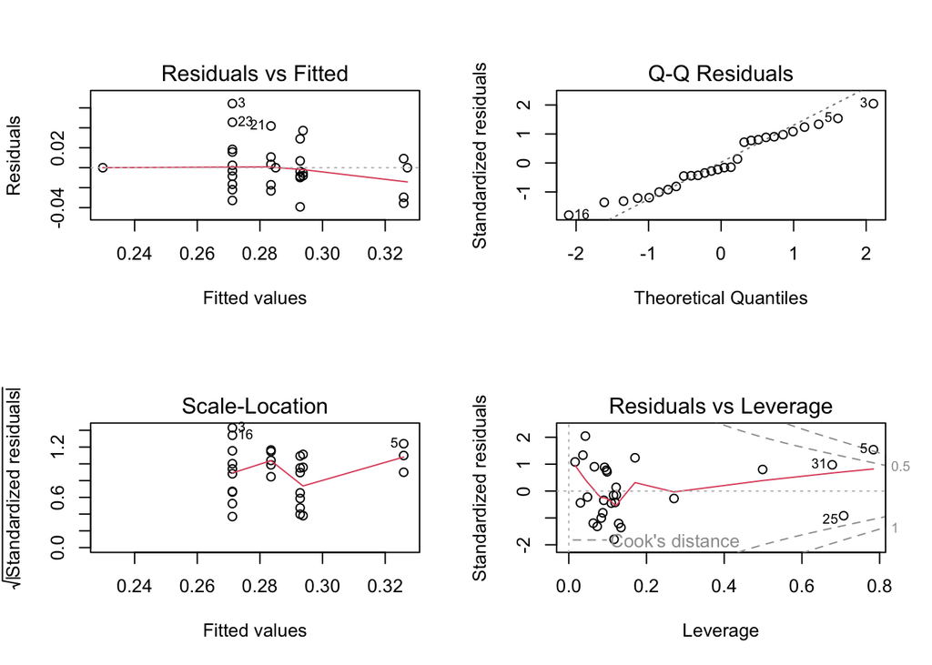

```r
# H2 ANOVA assumption checks

# 1) Diagnostic plots: residuals vs fitted, QQ plot, scale-location, leverage
par(mfrow = c(2,2))
plot(fit_h2)
```

```r
par(mfrow = c(1,1))

# 2) Normality of residuals (ANOVA assumes normal residuals)
shapiro_p <- shapiro.test(rstandard(fit_h2))$p.value

# 3) Homogeneity of variance across groups (i'm using levene because not all countries have 2 or more observations)
library(car)
levene_p <- car::leveneTest(prop_against ~ cultural_context, data = country_data)$`Pr(>F)`[1]

# 4) Influence check (check if a few countries dominate the result)
max_cooks <- max(cooks.distance(fit_h2))

h2_diag <- tibble::tibble(
  check = c(
    "Shapiro-Wilk p-value (residual normality)",
    "Levene p-value (homogeneity of variance)",
    "Max Cook's distance"
  ),
  value = c(shapiro_p, levene_p, max_cooks)
)

knitr::kable(h2_diag, digits = 4, caption = "H2 ANOVA diagnostics")
```

H2 ANOVA diagnostics

| check | value |
| --- | --- |
| Shapiro-Wilk p-value (residual normality) | 0.3279 |
| Levene p-value (homogeneity of variance) | 0.7764 |
| Max Cook’s distance | NaN |

These diagnostics test whether ANOVA assumptions are reasonable. The process is: (1) visually inspect residual plots for non-linearity and unequal variance, (2) test residual normality (Shapiro-Wilk), (3) test homogeneity of variance across groups (Levene), and (4) check influence (Cook’s distance).

```r
knitr::kable(h2_diag, digits = 4, caption = "H2 ANOVA diagnostics")
```

H2 ANOVA diagnostics

| check | value |
| --- | --- |
| Shapiro-Wilk p-value (residual normality) | 0.3279 |
| Levene p-value (homogeneity of variance) | 0.7764 |
| Max Cook’s distance | NaN |

### Interaction between cultural context and scenario type tests (H3):

For H3, the key question is whether scenario-type differences are the same in every cultural context. The interaction model allows scenario effects to vary by context. The ANOVA comparison between additive and interaction models is the direct test of this hypothesis. If the interaction model fits significantly better, it supports the claim that cultural differences depend on scenario type.

```r
fit_h3_add <- lm(prop_against ~ cultural_context + ScenarioTypeStrict, data = cell_data, weights = n)
fit_h3_int <- lm(prop_against ~ cultural_context * ScenarioTypeStrict, data = cell_data, weights = n)

h3_coefs <- broom::tidy(fit_h3_int, conf.int = TRUE)
h3_anova_compare <- broom::tidy(anova(fit_h3_add, fit_h3_int))
h3_glance <- broom::glance(fit_h3_int) %>%
  transmute(
    r_squared = r.squared,
    adj_r_squared = adj.r.squared,
    sigma = sigma,
    statistic_F = statistic,
    p_value_model = p.value,
    df_model = df,
    n_obs = nobs
  )

knitr::kable(h3_coefs, digits = 4, caption = "H3 interaction model coefficients")
```

H3 interaction model coefficients

| term | estimate | std.error | statistic | p.value | conf.low | conf.high |
| --- | --- | --- | --- | --- | --- | --- |
| (Intercept) | 0.2392 | 0.0113 | 21.0738 | 0.0000 | 0.2163 | 0.2620 |
| cultural_contextConfucian | 0.0978 | 0.0358 | 2.7341 | 0.0089 | 0.0258 | 0.1699 |
| cultural_contextEnglish | 0.0214 | 0.0140 | 1.5276 | 0.1335 | -0.0068 | 0.0495 |
| cultural_contextIslamic | -0.0022 | 0.0334 | -0.0664 | 0.9474 | -0.0695 | 0.0650 |
| cultural_contextLatinAmerica | 0.0298 | 0.0236 | 1.2633 | 0.2128 | -0.0177 | 0.0773 |
| cultural_contextOrthodox | -0.0029 | 0.0283 | -0.1037 | 0.9179 | -0.0600 | 0.0541 |
| cultural_contextProtestant | 0.0286 | 0.0189 | 1.5132 | 0.1371 | -0.0094 | 0.0666 |
| ScenarioTypeStrictFitness | 0.2276 | 0.0161 | 14.1246 | 0.0000 | 0.1951 | 0.2600 |
| ScenarioTypeStrictSpecies | -0.0821 | 0.0162 | -5.0727 | 0.0000 | -0.1147 | -0.0495 |
| ScenarioTypeStrictUtilitarian | -0.0347 | 0.0160 | -2.1664 | 0.0355 | -0.0669 | -0.0025 |
| cultural_contextConfucian:ScenarioTypeStrictFitness | -0.0553 | 0.0520 | -1.0625 | 0.2936 | -0.1600 | 0.0494 |
| cultural_contextEnglish:ScenarioTypeStrictFitness | -0.0258 | 0.0198 | -1.2984 | 0.2006 | -0.0657 | 0.0142 |
| cultural_contextIslamic:ScenarioTypeStrictFitness | -0.0700 | 0.0469 | -1.4920 | 0.1425 | -0.1645 | 0.0245 |
| cultural_contextLatinAmerica:ScenarioTypeStrictFitness | 0.0077 | 0.0336 | 0.2281 | 0.8206 | -0.0599 | 0.0752 |
| cultural_contextOrthodox:ScenarioTypeStrictFitness | 0.0151 | 0.0408 | 0.3688 | 0.7140 | -0.0671 | 0.0973 |
| cultural_contextProtestant:ScenarioTypeStrictFitness | -0.0234 | 0.0273 | -0.8564 | 0.3962 | -0.0785 | 0.0316 |
| cultural_contextConfucian:ScenarioTypeStrictSpecies | -0.0919 | 0.0505 | -1.8208 | 0.0751 | -0.1934 | 0.0097 |
| cultural_contextEnglish:ScenarioTypeStrictSpecies | 0.0207 | 0.0198 | 1.0461 | 0.3010 | -0.0192 | 0.0607 |
| cultural_contextIslamic:ScenarioTypeStrictSpecies | 0.1132 | 0.0482 | 2.3475 | 0.0233 | 0.0161 | 0.2102 |
| cultural_contextLatinAmerica:ScenarioTypeStrictSpecies | 0.1471 | 0.0334 | 4.4019 | 0.0001 | 0.0798 | 0.2144 |
| cultural_contextOrthodox:ScenarioTypeStrictSpecies | 0.0363 | 0.0406 | 0.8955 | 0.3752 | -0.0453 | 0.1180 |
| cultural_contextProtestant:ScenarioTypeStrictSpecies | 0.0018 | 0.0269 | 0.0683 | 0.9458 | -0.0523 | 0.0559 |
| cultural_contextConfucian:ScenarioTypeStrictUtilitarian | 0.0191 | 0.0515 | 0.3707 | 0.7125 | -0.0845 | 0.1227 |
| cultural_contextEnglish:ScenarioTypeStrictUtilitarian | -0.0083 | 0.0196 | -0.4248 | 0.6730 | -0.0479 | 0.0312 |
| cultural_contextIslamic:ScenarioTypeStrictUtilitarian | 0.0351 | 0.0469 | 0.7500 | 0.4571 | -0.0592 | 0.1295 |
| cultural_contextLatinAmerica:ScenarioTypeStrictUtilitarian | 0.0028 | 0.0334 | 0.0835 | 0.9338 | -0.0644 | 0.0700 |
| cultural_contextOrthodox:ScenarioTypeStrictUtilitarian | 0.0476 | 0.0399 | 1.1953 | 0.2381 | -0.0326 | 0.1278 |
| cultural_contextProtestant:ScenarioTypeStrictUtilitarian | 0.0172 | 0.0272 | 0.6325 | 0.5302 | -0.0376 | 0.0720 |

```r
knitr::kable(h3_anova_compare, digits = 4, caption = "H3 ANOVA model comparison (additive vs interaction)")
```

H3 ANOVA model comparison (additive vs interaction)

| term | df.residual | rss | df | sumsq | statistic | p.value |
| --- | --- | --- | --- | --- | --- | --- |
| prop_against ~ cultural_context + ScenarioTypeStrict | 64 | 21.2119 | NA | NA | NA | NA |
| prop_against ~ cultural_context * ScenarioTypeStrict | 46 | 9.5877 | 18 | 11.6242 | 3.0984 | 0.001 |

The ANOVA model comparison tests whether adding the interaction term improves fit beyond the additive model.

The additive-versus-interaction comparison is significant (F = 3.0984, p = 0.001), so adding `cultural_context × ScenarioTypeStrict` improves model fit. This supports **H3**: cultural differences are scenario-dependent, not constant across all dilemma types.

```r
knitr::kable(h3_glance, digits = 4, caption = "H3 interaction model fit summary")
```

H3 interaction model fit summary

| r_squared | adj_r_squared | sigma | statistic_F | p_value_model | df_model | n_obs |
| --- | --- | --- | --- | --- | --- | --- |
| 0.9711 | 0.9541 | 0.4565 | 57.2519 | 0 | 27 | 74 |

The interaction model has very high fit (R² = 0.9711, Adj. R² = 0.9541, n = 74). This indicates strong explanatory power, but it also uses many parameters relative to observations. To avoid over-interpretation, I prioritize the joint interaction test and broad pattern interpretation.

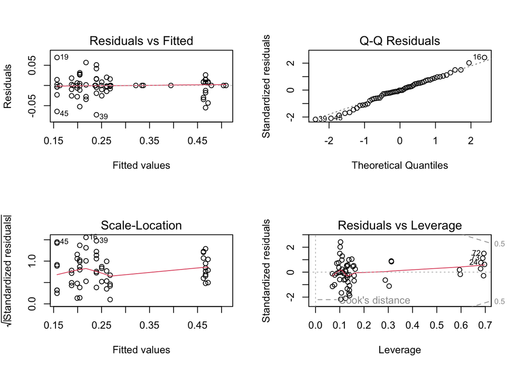

```r
# H3 diagnostics
par(mfrow = c(2,2))
plot(fit_h3_int)
```

```r
par(mfrow = c(1,1))

h3_diag <- tibble::tibble(
  check = c(
    "Shapiro-Wilk p-value (residual normality)",
    "Breusch-Pagan p-value (homoskedasticity)",
    "Max Cook's distance"
  ),
  value = c(
    shapiro.test(rstandard(fit_h3_int))$p.value,
    lmtest::bptest(fit_h3_int)$p.value,
    max(cooks.distance(fit_h3_int))
  )
)

knitr::kable(h3_diag, digits = 4, caption = "H3 interaction-model diagnostics")
```

H3 interaction-model diagnostics

| check | value |
| --- | --- |
| Shapiro-Wilk p-value (residual normality) | 0.8829 |
| Breusch-Pagan p-value (homoskedasticity) | 0.0000 |
| Max Cook’s distance | NaN |

The H3 diagnostics serve the same role as H2 diagnostics and suggest the model is informative but approximate. Given complexity and sample size, conclusions are strongest at the model-comparison level (interaction supported).

# Conclusion

This report tested whether deviation from global majority moral choices is structured by scenario type, cultural context, and their interaction.

For H1, the chi-square test found a strong association between scenario type and against-majority responses (very small p-value, effectively p < 0.001; non-trivial Cramer’s V). Practically, some dilemmas are much more divisive than others: in this sample, fitness scenarios are closest to split opinion, while species scenarios show stronger consensus.

For H3, the interaction model significantly improved fit over the additive model (ANOVA comparison p = 0.001). This means cultural differences are scenario-dependent rather than uniform across all dilemma types.

Overall, the findings support all three hypotheses. The broader implication is that when it comes to moral deviation, both the type of moral dilemma and social context matter, and they matter together.

Main limitations are (1) aggregation at country/context level may hide within-country variation, (2) some cultural categories contain few countries, and (3) linear-model assumptions are approximations for proportion outcomes. Future research should use individual-level multilevel models and include additional scenario dimensions to test robustness.